# Exploraty Data Analysis of the Effect of Road Traffic on NO2 Concentration in Marseille

Comparing weekdays to weekend.

Léo Zabrocki https://www.parisschoolofeconomics.eu/en/ (Paris School of Economics)https://www.parisschoolofeconomics.eu/en/ , Marion Leroutier https://marionleroutier.weebly.com/ (Mistra Center for Sustainable Markets, Stockholm School of Economics)https://www.hhs.se/en/persons/l/leroutier-marion/ , Marie-Abèle Bind https://biostatistics.massgeneral.org/faculty/marie-abele-bind-phd/ (Biostatistics Center, Massachusetts General Hospital)https://biostatistics.massgeneral.org/faculty/marie-abele-bind-phd/  
2021-11-02

In this document, we carry out an exploratory data analysis to investigate the parallel evolution of road traffic and nitrogen dioxide (NO$_{2}$) concentrations in Marseille. We focus on NO$_{2}$ as it is locally emitted by cars. We carry out a simple analysis where compare the concentration of NO$_{2}$ between weekdays and weekends as road traffic tends to decrease on Saturday and Sunday. The weekend/weedays contrast can be seen as a form of arbitrary variation in road traffic. We do not check the effects on other pollutants because they are less emitted locally.

In the following sections, we proceed as follows:

- We show that road traffic is indeed lower on weekends and that NO$_{2}$ concentrations fall at the end of the week.
- We check that weather covariates are balanced across weekdays and weekends.
- We compute the difference in NO$_{2}$ concentrations between weekdays and weekends.

**Should you have any questions, need help to reproduce the analysis or find coding errors, please do not hesitate to contact us at leo.zabrocki@psemail.eu and marion.leroutier@psemail.eu.**

# Required Packages

To reproduce exactly the `script_road_traffic_figures.html` document, we first need to have installed:

- the [R](https://www.r-project.org/) programming language on your computer
- [RStudio](https://rstudio.com/), an integrated development environment for R, which will allow you to knit the `script_road_traffic_figures.Rmd` file and interact with the R code chunks
- the [R Markdown](https://rmarkdown.rstudio.com/) package
- and the [Distill](https://rstudio.github.io/distill/) package which provides the template of this document.

Once everything is set up, we have to load the following packages:

```r
# load required packages
library(knitr) # for creating the R Markdown document
library(here) # for files paths organization
library(tidyverse) # for data manipulation and visualization
library(kableExtra) # for table formatting
library(Cairo) # for printing customed police of graphs
```

We use a custom ggplot2 theme for graphs:

```r
# load ggplot customed theme
source(here::here("2.scripts", "5.custom_ggplot2_theme", "script_custom_ggplot_theme.R"))
```

The theme is based on the fantastic [hrbrthemes](https://hrbrmstr.github.io/hrbrthemes/index.html) package. If you do not want to use this theme or are unable to install it because of fonts issues, you can use the `theme_mimimal()` included in the `ggplot2` package.

# Data Loading and Formatting

First, we load the daily data:

```r
# load data
data <- readRDS(here::here("1.data", "2.data_for_analysis", "0.main_data", "data_for_analysis_daily.RDS"))
```

We select relevant variables for our analysis:

```r
data <- data %>%
  select(# date variable
         "date",
         # pollutants
         "mean_no2_l", "mean_no2_sl",
         # maritime traffic variables
         "total_gross_tonnage_cruise",
         # weather parameters
         "temperature_average", "rainfall_height_dummy", "humidity_average", "wind_speed", "wind_direction_categories",
         # road traffic variables
         "road_traffic_flow_all",
         # calendar indicators
         "weekday", "weekend", "holidays_dummy", "bank_day_dummy", "month", "season", "year")
```

# Exploratory Data Analysis

### Road Traffic Variation by Day of the Week

We explore the patterns of road traffic. It is important to keep in mind that:

- We only use six stations in Marseille to create an aggregated measure of traffic.
- Some stations have an important number of missing values.
- Data are available only from 2011-01-01 to 2016-10-02.

We first plot the average road traffic by day of the week :

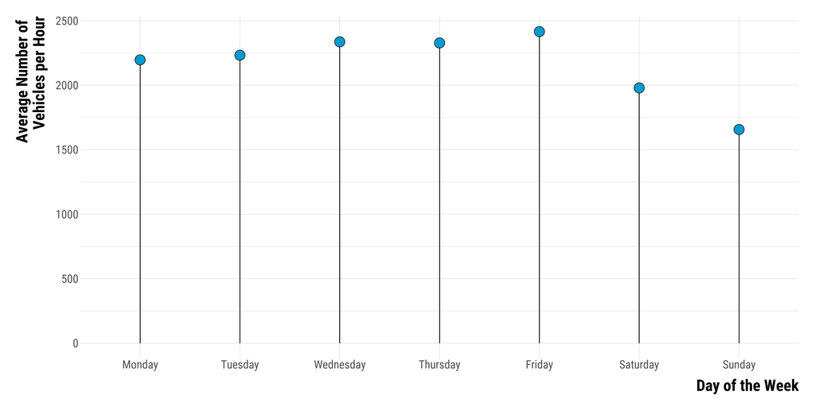

```r
# make the graph
graph_road_traffic_wd <- data %>%
  select(weekday, road_traffic_flow_all) %>%
  group_by(weekday) %>%
  summarise(road_traffic_flow_all = mean(road_traffic_flow_all, na.rm = TRUE)) %>%
  ggplot(., aes(x = weekday, y = road_traffic_flow_all)) +
  geom_segment(aes(x = weekday, xend = weekday, y = 0, yend = road_traffic_flow_all)) +
  geom_point(shape = 21, size = 8, colour = "black", fill = "deepskyblue3") +
  xlab("Day of the Week") + ylab("Average Number of \nVehicles per Hour") +
  custom_theme

# we print the graph
graph_road_traffic_wd
```

```r
# save the graph
ggsave(graph_road_traffic_wd, filename = here::here("3.outputs", "1.figures", "2.analysis_pollution", "2.road_traffic", "graph_road_traffic_wd.pdf"),
       width = 30, height = 15, units = "cm", device = cairo_pdf)
```

We then plot the empirical cumulative distribution of road traffic by weekdays and weekend:

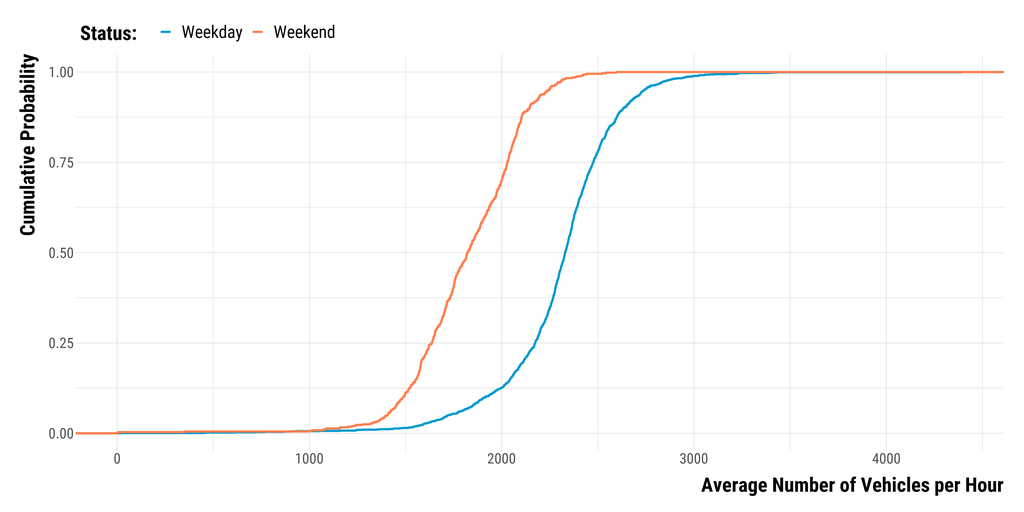

```r
graph_ecdf_road_traffic_we <- data %>%
  select(weekend, road_traffic_flow_all) %>%
  mutate(weekend = ifelse(weekend == 1, "Weekend", "Weekday")) %>%
  ggplot(., aes(x = road_traffic_flow_all, colour = weekend)) +
  stat_ecdf(size = 1.1) +
  scale_color_manual(values = c("deepskyblue3", "coral")) +
  ylab("Cumulative Probability") + xlab("Average Number of Vehicles per Hour") +
  labs(colour = "Status:") +
  custom_theme +
  theme(legend.position = "top", legend.justification = "left", legend.direction = "horizontal")

# we print the graph
graph_ecdf_road_traffic_we
```

```r
# save the graph
ggsave(graph_ecdf_road_traffic_we, filename = here::here("3.outputs", "1.figures", "2.analysis_pollution", "2.road_traffic", "graph_ecdf_road_traffic_we.pdf"),
       width = 30, height = 18, units = "cm", device = cairo_pdf)
```

### NO2 Variation by Day of the Week

We plot the average NO2 concentration by day of the week:

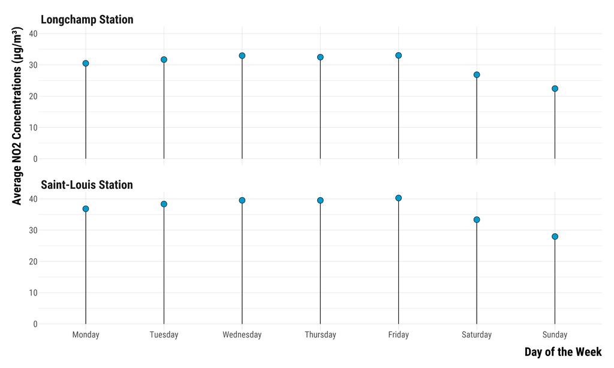

```r
# make the graph
graph_no2_wd <- data %>%
  select(weekday, mean_no2_l, mean_no2_sl) %>%
  rename("Longchamp Station" = mean_no2_l, "Saint-Louis Station" = mean_no2_sl) %>%
  pivot_longer(cols = -c(weekday), names_to = "station", values_to = "concentration") %>%
  group_by(weekday, station) %>%
  summarise(mean_no2 = mean(concentration, na.rm = TRUE)) %>%
  ggplot(., aes(x = weekday, y = mean_no2)) +
  geom_segment(aes(x = weekday, xend = weekday, y = 0, yend = mean_no2)) +
  geom_point(shape = 21, size = 6, colour = "black", fill = "deepskyblue3") +
  facet_wrap(~ station, ncol = 1) +
  xlab("Day of the Week") + ylab("Average NO2 Concentrations (µg/m³)") +
  custom_theme

# we print the graph
graph_no2_wd
```

```r
# save the graph
ggsave(graph_no2_wd, filename = here::here("3.outputs", "1.figures", "2.analysis_pollution", "2.road_traffic", "graph_no2_wd.pdf"),
       width = 30, height = 25, units = "cm", device = cairo_pdf)
```

We also plot the empirical cumulative distribution of NO$_{2}$ concentration by weekdays and weekend:

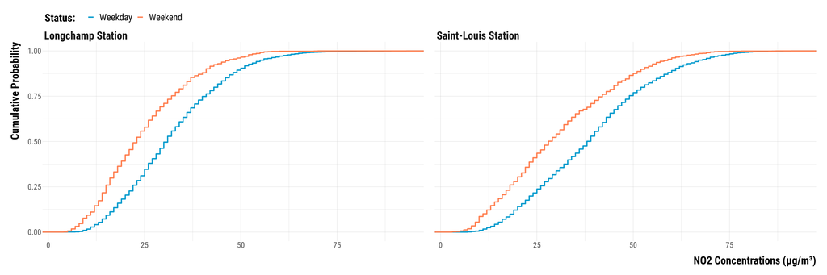

```r
# make the graph
graph_ecdf_no2_we <- data %>%
  select(weekend, mean_no2_l, mean_no2_sl) %>%
  mutate(weekend = ifelse(weekend == 1, "Weekend", "Weekday")) %>%
  rename("Longchamp Station" = mean_no2_l, "Saint-Louis Station" = mean_no2_sl) %>%
  pivot_longer(cols = -c(weekend), names_to = "station", values_to = "concentration") %>%
  ggplot(., aes(x = concentration, colour = weekend)) +
  stat_ecdf(size = 1.1) +
  scale_color_manual(values = c("deepskyblue3", "coral")) +
  facet_wrap(~ station) +
  ylab("Cumulative Probability") + xlab("NO2 Concentrations (µg/m³)") +
  labs(colour = "Status:") +
  custom_theme +
  theme(legend.position = "top", legend.justification = "left", legend.direction = "horizontal")

# we print the graph
graph_ecdf_no2_we
```

```r
# save the graph
ggsave(graph_ecdf_no2_we, filename = here::here("3.outputs", "1.figures", "2.analysis_pollution", "2.road_traffic",  "graph_ecdf_no2_we.pdf"),
       width = 40, height = 15, units = "cm", device = cairo_pdf)
```

### Average Total Gross Tonnage of Cruise Vessels by Day of the Week

We plot the average total gross tonnage of vessels by day of the week:

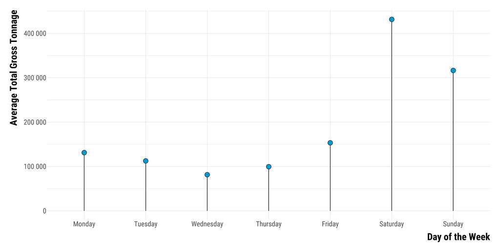

```r
graph_gross_tonnage_cruise_wd <- data %>%
  select(weekday, total_gross_tonnage_cruise) %>%
  group_by(weekday) %>%
  summarise(total_gross_tonnage_cruise = mean(total_gross_tonnage_cruise, na.rm = TRUE)) %>%
  ggplot(., aes(x = weekday, y = total_gross_tonnage_cruise)) +
  geom_segment(aes(x = weekday, xend = weekday, y = 0, yend = total_gross_tonnage_cruise)) +
  geom_point(shape = 21, size = 6, colour = "black", fill = "deepskyblue3") +
  scale_y_continuous(breaks = scales::pretty_breaks(n = 5), labels = function(x) format(x, big.mark = " ", scientific = FALSE)) +
  xlab("Day of the Week") + ylab("Average Total Gross Tonnage") +
  custom_theme

# we print the graph
graph_gross_tonnage_cruise_wd
```

```r
# save the graph
ggsave(
  graph_gross_tonnage_cruise_wd,
  filename = here::here(
    "3.outputs",
    "1.figures",
    "2.analysis_pollution",
    "2.road_traffic",
    "graph_gross_tonnage_cruise_wd.pdf"
  ),
  width = 30,
  height = 15,
  units = "cm",
  device = cairo_pdf
)
```

# Weather Covariates Balance

We can check that the weekends and weekdays are similar for weather covariates. For continuous weather covariates, we draw boxplots for treated and control groups:

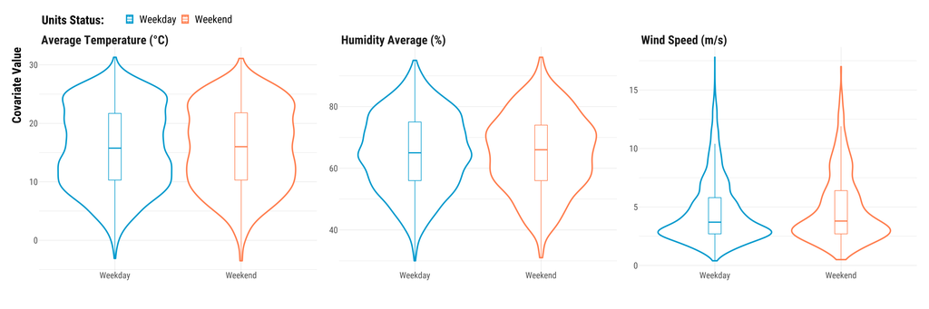

```r
# we select control variables and store them in a long dataframe
data_weather_continuous_variables <- data %>%
  mutate(weekend = ifelse(weekend == 1, "Weekend", "Weekday")) %>%
  select(temperature_average,
         humidity_average,
         wind_speed,
         weekend) %>%
  pivot_longer(cols = -c(weekend),
               names_to = "variable",
               values_to = "values") %>%
  mutate(variable = case_when(variable == "temperature_average" ~ "Average Temperature (°C)",
                              variable == "humidity_average" ~ "Humidity Average (%)",
                              variable == "wind_speed" ~ "Wind Speed (m/s)"))


graph_boxplot_continuous_weather <- ggplot(data_weather_continuous_variables, aes(x = weekend, y = values, colour = weekend)) +
  geom_violin(size = 1.2) +
  geom_boxplot(width=0.1, outlier.shape=NA) +
  scale_color_manual(values=c("deepskyblue3", "coral")) +
  ylab("Covariate Value") +
  xlab("") +
  labs(colour = "Units Status:") +
  facet_wrap(~variable, scale = "free", ncol = 3) +
  custom_theme +
  theme(legend.position = "top", legend.justification = "left", legend.direction = "horizontal")

# we print the graph
graph_boxplot_continuous_weather
```

```r
# save the graph
ggsave(graph_boxplot_continuous_weather, filename = here::here("3.outputs", "1.figures", "2.analysis_pollution", "2.road_traffic",  "graph_boxplot_continuous_weather.pdf"), width = 40, height = 15, units = "cm", device = cairo_pdf)
```

For the rainfall dummy and the wind direction categories, we plot the proportions:

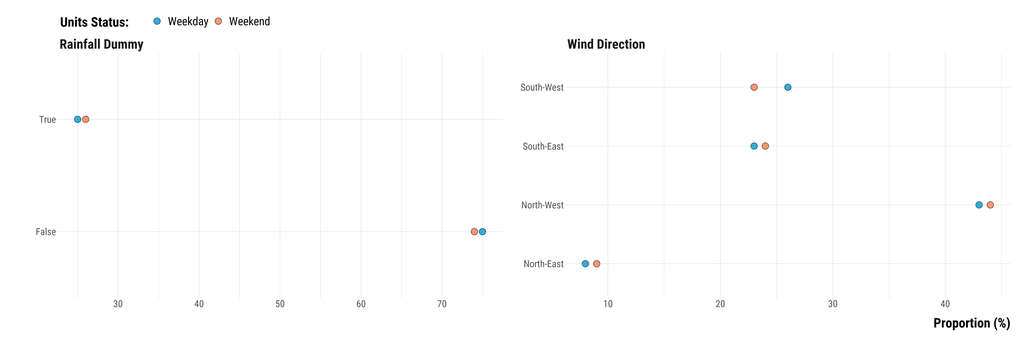

```r
# we select the rainfall variables
data_weather_categorical <- data %>%
  mutate(weekend = ifelse(weekend == 1, "Weekend", "Weekday")) %>%
  select(rainfall_height_dummy,
         wind_direction_categories,
         weekend) %>%
  drop_na() %>%
  mutate_at(vars(rainfall_height_dummy), ~ ifelse(. == 1, "True", "False")) %>%
  mutate_all( ~ as.character(.)) %>%
  pivot_longer(cols = -c(weekend),
               names_to = "variable",
               values_to = "values") %>%
  # group by weekend, variable and values
  group_by(weekend, variable, values) %>%
  # compute the number of observations
  summarise(n = n()) %>%
  # compute the proportion
  mutate(freq = round(n / sum(n) * 100, 0)) %>%
  ungroup() %>%
  mutate(
    variable = case_when(
      variable == "wind_direction_categories" ~ "Wind Direction",
      variable == "rainfall_height_dummy" ~ "Rainfall Dummy"
    )
  )

# build the graph
graph_categorical_weather <-
  ggplot(data_weather_categorical, aes(x = freq, y = values, fill = weekend)) +
  geom_point(shape = 21,
             size = 6,
             alpha = 0.8) +
  scale_fill_manual(values = c("deepskyblue3", "coral")) +
  facet_wrap( ~ variable, scales = "free") +
  xlab("Proportion (%)") +
  ylab("") +
  labs(fill = "Units Status:") +
  custom_theme +
  theme(
    legend.position = "top",
    legend.justification = "left",
    legend.direction = "horizontal"
  )

# we print the graph
graph_categorical_weather
```

```r
# save the graph
ggsave(
  graph_categorical_weather,
  filename = here::here(
  "3.outputs", "1.figures", "2.analysis_pollution", "2.road_traffic",
    "graph_categorical_weather.pdf"
  ),
  width = 40,
  height = 20,
  units = "cm",
  device = cairo_pdf
)
```

# Weekend Effect on Road Traffic and NO$_{2}$ Concentrations

We calculate the average differences in road traffic and NO$_{2}$ concentrations between weekends and weekdays.

### Weekend Effect on Road Traffic

We compute the average in the flow of vehicles between weekdays and weekends:

```r
# compute average effect
data %>%
  filter(!is.na(road_traffic_flow_all)) %>%
  summarise(average_difference = mean(road_traffic_flow_all[weekend == 1]) - mean(road_traffic_flow_all[weekend == 0]))
```

```
# A tibble: 1 x 1
  average_difference
               <dbl>
1              -484.
```

### Weekend Effect on NO2 concentrations

We compute the average effect of weekends on NO2 concentrations.

```r
# compute mean difference in no2 for the two stations
data %>%
  select(weekend, mean_no2_l, mean_no2_sl) %>%
  pivot_longer(cols = -c(weekend),
               names_to = "station",
               values_to = "concentration") %>%
  group_by(station) %>%
  summarise(average_difference = round(mean(concentration[weekend == 1], na.rm = TRUE) - mean(concentration[weekend == 0], na.rm = TRUE), 1))
```

```
# A tibble: 2 x 2
  station     average_difference
  <chr>                    <dbl>
1 mean_no2_l                -7.5
2 mean_no2_sl               -8.2
```